# CA 2008 Oil Spill Events

Mariano Viz

20/02/2021

**Data source:** California Department of Fish and Wildlife (CDFW), Office of Spill Prevention and Response (OSPR). (2009). Oil Spill Incident Tracking, 2008. California Department of Fish and Wildlife. Available at: https://map.dfg.ca.gov/metadata/ds0394.html

## Summary

In this report, I explore the spatial distribution of oil spill events in California in 2008. First, I make an interactive map showing the location of inland and marine oil spill incidents. Then, I examine the distribution of inland oil spill events and make a static chloropleth map displaying counts of inland spill incidents by county. Data: CDFW (2009).

```r
# Read in data, update col names, and check projection:


#Read in Oil Spill Incident Tracking data and update col names to lowercase:
oil_spill <- read_sf(here("Oil_Spill_Incident_Tracking_%5Bds394%5D-shp"), layer = "Oil_Spill_Incident_Tracking_%5Bds394%5D") %>%
  clean_names() %>%
  rename(Location = inlandmari) #rename col showing spill location

# Check Oil Spill Incident Tracking data projection:
#st_crs(oil_spill) # WGS 84 (EPSG,3857)


# Read in the CA county data, update col names to lowercase, and keep only names:
ca_counties <- read_sf(here("ca_counties"), layer = "CA_Counties_TIGER2016") %>%
  clean_names() %>%
  select(name)

# Check the CA county projection
  #st_crs(ca_counties) # WGS 84 (EPSG,3857)
    #Same Projection as Oil Spill Incident Tracking data (no need to set or transform CRS)
```

## Exploratory interactive map of oil spill events

```r
# Check data with a quick ggplot:
#ggplot() +
  #geom_sf(data = ca_counties) +
  #geom_sf(data = oil_spill, aes(color = Location), size = 0.5)

#Interactive plot (tmap)
tmap_mode("view")

tm_shape(oil_spill) +
  tm_dots("Location")
```

[interactive chart not shown]

**Figure 1.** Oil spill events in California in 2008. Events are divided based on location. Green and yellow points indicate inland and marine event locations, respectively. Data: CDFW (2009).

## Static chloropleth map showing counts of inland oil spill events by county

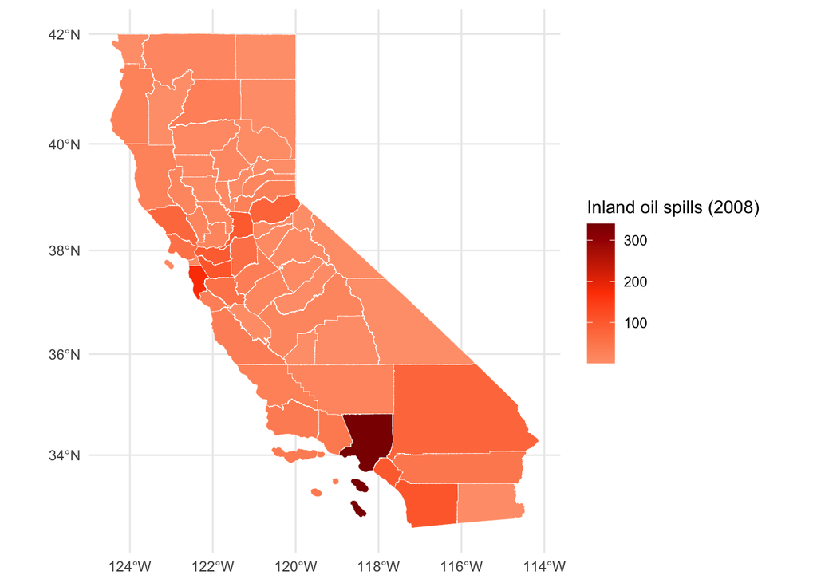

```r
#Only keep inland oil spills:
inland_oil_spill <- oil_spill %>%
  filter(Location == "Inland")

#Spatial join of data:
ca_oil_spill <- ca_counties %>%
  st_join(inland_oil_spill)

#Counts of inland oil spills by county:
oil_spill_counts <- ca_oil_spill %>%
  count(name)
#oil_spill_subset

#Static chloropleth map:
ggplot(data = oil_spill_counts) +
  geom_sf(aes(fill = n), color = "white", size = 0.1) +
  scale_fill_gradientn(colors = c("lightsalmon1","orangered1","red4")) +
  theme_minimal() +
  labs(fill = "Inland oil spills (2008)")
```

**Figure 2.** Counts of California’s inland oil spill events by county in 2008. County color, from salmon to dark red, reflects the number of inland oil spill incidents. Data: CDFW (2009).